# Part I - Prosper Loan Data Exploration

#### by Murielle Souvenir LOKONON

- Introduction
- Preliminary Wrangling
- Univariate Exploration
- Bivariate Exploration
- Multivariate exploration
- Conclusion

## Introduction

This document explores a dataset containing 113,937 loans with 81 variables on each loan, including loan amount, borrower rate (or interest rate), current loan status, borrower income, and more.

### Dataset column

> They are more columns description [here](https://www.google.com/url?q=https://docs.google.com/spreadsheet/ccc?key%3D0AllIqIyvWZdadDd5NTlqZ1pBMHlsUjdrOTZHaVBuSlE%26usp%3Dsharing&sa=D&ust=1554486256024000).

> The dataset is available [here](https://www.google.com/url?q=https://s3.amazonaws.com/udacity-hosted-downloads/ud651/prosperLoanData.csv&sa=D&ust=1581581520570000).

### Interest

During my analysis I'm most interested in figuring out what factors affect a loan’s outcome status. Also I have tried to provide answers to the some questions like:

- How the loan staus is distributed in the dataset?
- What is the income range of the majority of the borrowers?
- How the borrower's rate is behaving ?
- What is the most frequent term duration choosed by the borrowers?
- How the borrower's prosper score is behaving ?
- Are the borrowers mostly homeowners?
- Are the revenues of the borrowers for the most part verifiable?
- Have the borrowers a large number of open credit at the time the credit profile was pulled?
- Have the borrowers a large number of delinquencies during the last 7 years?
- Have the borrowers a high amount of debt considering their income
- What is the month income of the most borrowers?
- What is the monthly loan payment of many borrowers ?
- How the borrower's loan original amount is behaving ?
- Are the differents features corralated? And what are their relationships?
- What is the relationship of the loan status with the DelinquenciesLast7Years and the DebtToIncomeRatio
- What is the relationship of the loan status with the ProsperScore and the BorrowerRate
- What is the relationship of the loan status with the borrower rate and Income range
- What is the relationship of the loan status with StatedMonthlyIncome and MonthlyLoanPayment
- What is the relationship of the prosper score with the BorrowerRate and DebtToIncomeRatio
- What is the relationship of the prosper score with the BorrowerRate and DelinquenciesLast7Years
- What is the relationship of the prosper score with DelinquenciesLast7Years and DebtToIncomeRatio
- What is the relationship of the prosper score with the BorrowerRate, LoanOriginalAmou and IncomeRange

## Preliminary Wrangling

```python
# import all packages and set plots to be embedded inline
import numpy as np
import pandas as pd
import matplotlib.pyplot as plt
import seaborn as sb
from matplotlib import rcParams

%matplotlib inline
```

> Loading of our dataset and describe of its properties through the questions below.

```python
df = pd.read_csv('prosperLoanData.csv')

#checking if it is correctly imported
df.head(1)
```

|  | ListingKey | ListingNumber | ListingCreationDate | CreditGrade | Term | LoanStatus | ClosedDate | BorrowerAPR | BorrowerRate | LenderYield | ... | LP_ServiceFees | LP_CollectionFees | LP_GrossPrincipalLoss | LP_NetPrincipalLoss | LP_NonPrincipalRecoverypayments | PercentFunded | Recommendations | InvestmentFromFriendsCount | InvestmentFromFriendsAmount | Investors |
| --- | --- | --- | --- | --- | --- | --- | --- | --- | --- | --- | --- | --- | --- | --- | --- | --- | --- | --- | --- | --- | --- |
| 0 | 1021339766868145413AB3B | 193129 | 2007-08-26 19:09:29.263000000 | C | 36 | Completed | 2009-08-14 00:00:00 | 0.16516 | 0.158 | 0.138 | ... | -133.18 | 0.0 | 0.0 | 0.0 | 0.0 | 1.0 | 0 | 0 | 0.0 | 258 |

1 rows × 81 columns

```python
# high-level overview of data shape and composition
print(df.shape)
print(df.dtypes)
print(df.sample(10))
```

```
(113937, 81)
ListingKey                              object
ListingNumber                            int64
ListingCreationDate                     object
CreditGrade                             object
Term                                     int64
LoanStatus                              object
ClosedDate                              object
BorrowerAPR                            float64
BorrowerRate                           float64
LenderYield                            float64
EstimatedEffectiveYield                float64
EstimatedLoss                          float64
EstimatedReturn                        float64
ProsperRating (numeric)                float64
ProsperRating (Alpha)                   object
ProsperScore                           float64
ListingCategory (numeric)                int64
BorrowerState                           object
Occupation                              object
EmploymentStatus                        object
EmploymentStatusDuration               float64
IsBorrowerHomeowner                       bool
CurrentlyInGroup                          bool
GroupKey                                object
DateCreditPulled                        object
CreditScoreRangeLower                  float64
CreditScoreRangeUpper                  float64
FirstRecordedCreditLine                 object
CurrentCreditLines                     float64
OpenCreditLines                        float64
                                        ...
TotalProsperLoans                      float64
TotalProsperPaymentsBilled             float64
OnTimeProsperPayments                  float64
ProsperPaymentsLessThanOneMonthLate    float64
ProsperPaymentsOneMonthPlusLate        float64
ProsperPrincipalBorrowed               float64
ProsperPrincipalOutstanding            float64
ScorexChangeAtTimeOfListing            float64
```

[output cut: 81 more lines]

```
79601                             0.0            1.0                0

      InvestmentFromFriendsCount InvestmentFromFriendsAmount Investors
43043                          0                         0.0       210
43526                          0                         0.0         1
37171                          0                         0.0        24
45371                          0                         0.0        22
23912                          0                         0.0         1
7904                           0                         0.0       150
25811                          0                         0.0       127
62027                          0                         0.0         1
5364                           0                         0.0        33
79601                          0                         0.0        13

[10 rows x 81 columns]
```

```python
df.IncomeRange.value_counts()
```

```
$25,000-49,999    32192
$50,000-74,999    31050
$100,000+         17337
$75,000-99,999    16916
Not displayed      7741
$1-24,999          7274
Not employed        806
$0                  621
Name: IncomeRange, dtype: int64
```

```python
df.Term.value_counts()
```

```
36    87778
60    24545
12     1614
Name: Term, dtype: int64
```

```python
df.ProsperScore.value_counts()
```

```
4.0     12595
6.0     12278
8.0     12053
7.0     10597
5.0      9813
3.0      7642
9.0      6911
2.0      5766
10.0     4750
11.0     1456
1.0       992
Name: ProsperScore, dtype: int64
```

### What is the structure of your dataset?

There are 113937 loans in the dataset with 81 features. Most variables are numeric in nature, but the IncomeRange and Term variables are ordered factors with the following levels. The ProsperScore too ( A custom risk score built using historical Prosper data. The score ranges from 1-10, with 10 being the best, or lowest risk score. Applicable for loans originated after July 2009.)

(smaller or bad) ——> (largest or best)

IncomeRange: Not employed or $0, $1-24,999, $25,000-49,999, $50,000-74,999, $75,000-99,999, $100,000+

ProsperScore: 1, 2, 3, 4, 5, 6, 7, 8, 9, 10

### What is/are the main feature(s) of interest in your dataset?

I'm most interested in figuring out what factors affect a loan’s outcome status.

### What features in the dataset do you think will help support your investigation into your feature(s) of interest?

I expect that the following variables will have effect on LoanStatus because of their meanings.

- LoanOriginalAmount
- Term (The length of the loan expressed in months),
- BorrowerRate(The Borrower's interest rate for this loan),
- ListingCategory,
- IsBorrowerHomeowner
- ProsperScore (A custom risk score built using historical Prosper data)
- OpenCreditLines (Number of open credit lines at the time the credit profile was pulled.)
- DelinquenciesLast7Years (Number of delinquencies in the past 7 years at the time the credit profile was pulled.)
- DebtToIncomeRatio
- IncomeRange
- IncomeVerifiable
- StatedMonthlyIncome (The monthly income the borrower stated at the time the listing was created.)
- MonthlyLoanPayment (The scheduled monthly loan payment.)

### Wrangling

```python
df_clean = df.copy()
```

```python
# dataset after wrangling
df_clean.info()
```

```
<class 'pandas.core.frame.DataFrame'>
RangeIndex: 113937 entries, 0 to 113936
Data columns (total 81 columns):
ListingKey                             113937 non-null object
ListingNumber                          113937 non-null int64
ListingCreationDate                    113937 non-null object
CreditGrade                            28953 non-null object
Term                                   113937 non-null int64
LoanStatus                             113937 non-null object
ClosedDate                             55089 non-null object
BorrowerAPR                            113912 non-null float64
BorrowerRate                           113937 non-null float64
LenderYield                            113937 non-null float64
EstimatedEffectiveYield                84853 non-null float64
EstimatedLoss                          84853 non-null float64
EstimatedReturn                        84853 non-null float64
ProsperRating (numeric)                84853 non-null float64
ProsperRating (Alpha)                  84853 non-null object
ProsperScore                           84853 non-null float64
ListingCategory (numeric)              113937 non-null int64
BorrowerState                          108422 non-null object
Occupation                             110349 non-null object
EmploymentStatus                       111682 non-null object
EmploymentStatusDuration               106312 non-null float64
IsBorrowerHomeowner                    113937 non-null bool
CurrentlyInGroup                       113937 non-null bool
GroupKey                               13341 non-null object
DateCreditPulled                       113937 non-null object
CreditScoreRangeLower                  113346 non-null float64
CreditScoreRangeUpper                  113346 non-null float64
FirstRecordedCreditLine                113240 non-null object
CurrentCreditLines                     106333 non-null float64
OpenCreditLines                        106333 non-null float64
TotalCreditLinespast7years             113240 non-null float64
OpenRevolvingAccounts                  113937 non-null int64
OpenRevolvingMonthlyPayment            113937 non-null float64
InquiriesLast6Months                   113240 non-null float64
TotalInquiries                         112778 non-null float64
CurrentDelinquencies                   113240 non-null float64
AmountDelinquent                       106315 non-null float64
```

[output cut: 31 more lines]

```
LP_CustomerPayments                    113937 non-null float64
LP_CustomerPrincipalPayments           113937 non-null float64
LP_InterestandFees                     113937 non-null float64
LP_ServiceFees                         113937 non-null float64
LP_CollectionFees                      113937 non-null float64
LP_GrossPrincipalLoss                  113937 non-null float64
LP_NetPrincipalLoss                    113937 non-null float64
LP_NonPrincipalRecoverypayments        113937 non-null float64
PercentFunded                          113937 non-null float64
Recommendations                        113937 non-null int64
InvestmentFromFriendsCount             113937 non-null int64
InvestmentFromFriendsAmount            113937 non-null float64
Investors                              113937 non-null int64
dtypes: bool(3), float64(50), int64(11), object(17)
memory usage: 68.1+ MB
```

```python
# dataset before wrangling
df_clean.info()
```

```
<class 'pandas.core.frame.DataFrame'>
RangeIndex: 113937 entries, 0 to 113936
Data columns (total 81 columns):
ListingKey                             113937 non-null object
ListingNumber                          113937 non-null int64
ListingCreationDate                    113937 non-null object
CreditGrade                            28953 non-null object
Term                                   113937 non-null int64
LoanStatus                             113937 non-null object
ClosedDate                             55089 non-null object
BorrowerAPR                            113912 non-null float64
BorrowerRate                           113937 non-null float64
LenderYield                            113937 non-null float64
EstimatedEffectiveYield                84853 non-null float64
EstimatedLoss                          84853 non-null float64
EstimatedReturn                        84853 non-null float64
ProsperRating (numeric)                84853 non-null float64
ProsperRating (Alpha)                  84853 non-null object
ProsperScore                           84853 non-null float64
ListingCategory (numeric)              113937 non-null int64
BorrowerState                          108422 non-null object
Occupation                             110349 non-null object
EmploymentStatus                       111682 non-null object
EmploymentStatusDuration               106312 non-null float64
IsBorrowerHomeowner                    113937 non-null bool
CurrentlyInGroup                       113937 non-null bool
GroupKey                               13341 non-null object
DateCreditPulled                       113937 non-null object
CreditScoreRangeLower                  113346 non-null float64
CreditScoreRangeUpper                  113346 non-null float64
FirstRecordedCreditLine                113240 non-null object
CurrentCreditLines                     106333 non-null float64
OpenCreditLines                        106333 non-null float64
TotalCreditLinespast7years             113240 non-null float64
OpenRevolvingAccounts                  113937 non-null int64
OpenRevolvingMonthlyPayment            113937 non-null float64
InquiriesLast6Months                   113240 non-null float64
TotalInquiries                         112778 non-null float64
CurrentDelinquencies                   113240 non-null float64
AmountDelinquent                       106315 non-null float64
```

[output cut: 31 more lines]

```
LP_CustomerPayments                    113937 non-null float64
LP_CustomerPrincipalPayments           113937 non-null float64
LP_InterestandFees                     113937 non-null float64
LP_ServiceFees                         113937 non-null float64
LP_CollectionFees                      113937 non-null float64
LP_GrossPrincipalLoss                  113937 non-null float64
LP_NetPrincipalLoss                    113937 non-null float64
LP_NonPrincipalRecoverypayments        113937 non-null float64
PercentFunded                          113937 non-null float64
Recommendations                        113937 non-null int64
InvestmentFromFriendsCount             113937 non-null int64
InvestmentFromFriendsAmount            113937 non-null float64
Investors                              113937 non-null int64
dtypes: bool(3), float64(50), int64(11), object(17)
memory usage: 68.1+ MB
```

**Let's firstly remove unnecessary columns**

```python
#Columns to keep
columns = ['ListingKey','Term','LoanOriginalAmount','BorrowerRate','IsBorrowerHomeowner','ListingCategory','OpenCreditLines',
           'DelinquenciesLast7Years','DebtToIncomeRatio', 'ProsperScore','IncomeRange',
           'IncomeVerifiable','StatedMonthlyIncome','MonthlyLoanPayment','LoanStatus']
#Drop all other columns
df_clean.drop(df.columns.difference(columns),1,inplace=True)

#test if it's done
df_clean.dtypes
```

```
ListingKey                  object
Term                         int64
LoanStatus                  object
BorrowerRate               float64
ProsperScore               float64
IsBorrowerHomeowner           bool
OpenCreditLines            float64
DelinquenciesLast7Years    float64
DebtToIncomeRatio          float64
IncomeRange                 object
IncomeVerifiable              bool
StatedMonthlyIncome        float64
LoanOriginalAmount           int64
MonthlyLoanPayment         float64
dtype: object
```

**Let's convert IncomeRange and Term into ordered categorical type. I'll convert ProsperScore after correction of 11 prosper score value problem**

```python
#function to convert to ordered categorical type
def convert_to_ordered_categorical_type(df, column, ordered_list):
    #convert columns into ordered categorical type
    ordered_var = pd.api.types.CategoricalDtype(ordered = True,
                                            categories = ordered_list)
    df[column] = df[column].astype(ordered_var)
```

```python
#old value
print(df_clean.IncomeRange.dtypes)
print(df_clean.Term.dtypes)
```

```
object
int64
```

```python
#Replace Not empoyed by $0 and  Not displayed by Nan
#df_clean.loc[df_clean['IncomeRange'] == "Not employed", 'IncomeRange'] = "$0"
df_clean.loc[df_clean['IncomeRange'] == "Not employed", 'IncomeRange'] = np.nan
df_clean.loc[df_clean['IncomeRange'] == "Not displayed", 'IncomeRange'] = np.nan

#defining order
IncomeRange = ["$0", "$1-24,999", "$25,000-49,999", "$50,000-74,999", "$75,000-99,999", "$100,000+"]
Term = [12,30,60]

#convert IncomeRange into ordered categorical type
convert_to_ordered_categorical_type(df_clean,"IncomeRange",IncomeRange)

#convert Term into ordered categorical type
convert_to_ordered_categorical_type(df_clean,"Term",Term)
```

**OpenCreditLines and DelinquenciesLast7Years should be numbers**

```python
df_clean['OpenCreditLines'] = df_clean['OpenCreditLines'].fillna(0.0).astype(int)
df_clean['DelinquenciesLast7Years'] = df_clean['DelinquenciesLast7Years'].fillna(0.0).astype(int)
```

```python
#checking if it is okay
df_clean.dtypes
```

```
ListingKey                   object
Term                       category
LoanStatus                   object
BorrowerRate                float64
ProsperScore                float64
IsBorrowerHomeowner            bool
OpenCreditLines               int64
DelinquenciesLast7Years       int64
DebtToIncomeRatio           float64
IncomeRange                category
IncomeVerifiable               bool
StatedMonthlyIncome         float64
LoanOriginalAmount            int64
MonthlyLoanPayment          float64
dtype: object
```

**other issues**

```python
#checking them

# descriptive statistics for numeric variables
print(df_clean.describe())
```

```
        BorrowerRate  ProsperScore  OpenCreditLines  DelinquenciesLast7Years  \
count  113937.000000  84853.000000    113937.000000            113937.000000
mean        0.192764      5.950067         8.642153                 4.118881
std         0.074818      2.376501         5.374413                10.123325
min         0.000000      1.000000         0.000000                 0.000000
25%         0.134000      4.000000         5.000000                 0.000000
50%         0.184000      6.000000         8.000000                 0.000000
75%         0.250000      8.000000        12.000000                 3.000000
max         0.497500     11.000000        54.000000                99.000000

       DebtToIncomeRatio  StatedMonthlyIncome  LoanOriginalAmount  \
count      105383.000000         1.139370e+05        113937.00000
mean            0.275947         5.608026e+03          8337.01385
std             0.551759         7.478497e+03          6245.80058
min             0.000000         0.000000e+00          1000.00000
25%             0.140000         3.200333e+03          4000.00000
50%             0.220000         4.666667e+03          6500.00000
75%             0.320000         6.825000e+03         12000.00000
max            10.010000         1.750003e+06         35000.00000

       MonthlyLoanPayment
count       113937.000000
mean           272.475783
std            192.697812
min              0.000000
25%            131.620000
50%            217.740000
75%            371.580000
max           2251.510000
```

```python
#Booleans values checking
print(df_clean.IncomeVerifiable.value_counts())
print(df_clean.IsBorrowerHomeowner.value_counts())
```

```
True     105268
False      8669
Name: IncomeVerifiable, dtype: int64
True     57478
False    56459
Name: IsBorrowerHomeowner, dtype: int64
```

```python
#checking duplicated loans
df_clean.ListingKey.duplicated().sum()
```

```
871
```

```python
#missing values
df_clean.isna().sum()
```

```
ListingKey                     0
Term                       87778
LoanStatus                     0
BorrowerRate                   0
ProsperScore               29084
IsBorrowerHomeowner            0
OpenCreditLines                0
DelinquenciesLast7Years        0
DebtToIncomeRatio           8554
IncomeRange                 8547
IncomeVerifiable               0
StatedMonthlyIncome            0
LoanOriginalAmount             0
MonthlyLoanPayment             0
dtype: int64
```

1. The max value of ProsperScore should be 10 not 11
2. They are missing values for some columns
3. We have duplicated loans

#### Cleaning those issues

##### #1. The max value of ProsperScore should be 10 not 11

```python
#getting record with ProsperScore more than 10
df_clean.query("ProsperScore > 10")
```

|  | ListingKey | Term | LoanStatus | BorrowerRate | ProsperScore | IsBorrowerHomeowner | OpenCreditLines | DelinquenciesLast7Years | DebtToIncomeRatio | IncomeRange | IncomeVerifiable | StatedMonthlyIncome | LoanOriginalAmount | MonthlyLoanPayment |
| --- | --- | --- | --- | --- | --- | --- | --- | --- | --- | --- | --- | --- | --- | --- |
| 9 | 0F043596202561788EA13D5 | NaN | Current | 0.0629 | 11.0 | True | 16 | 0 | 0.25 | $25,000-49,999 | True | 3333.333333 | 10000 | 305.54 |
| 69 | 0F37360159310530849DA23 | 60.0 | Current | 0.1139 | 11.0 | True | 5 | 0 | NaN | $25,000-49,999 | False | 2700.000000 | 9000 | 197.44 |
| 158 | 108E36027739898797E47EC | NaN | Current | 0.0809 | 11.0 | False | 8 | 5 | 0.05 | $75,000-99,999 | True | 6666.666667 | 5500 | 172.58 |
| 224 | 2F293599751524472C82DEA | NaN | Current | 0.1099 | 11.0 | True | 16 | 0 | 0.11 | $100,000+ | True | 33333.333333 | 30000 | 982.02 |
| 236 | 11D335932344051959C94C6 | NaN | Current | 0.0605 | 11.0 | True | 11 | 0 | 0.14 | $25,000-49,999 | True | 4083.333333 | 9000 | 274.00 |
| 277 | 2EFC36028887817232507BC | 60.0 | Current | 0.1355 | 11.0 | False | 8 | 0 | 0.19 | $75,000-99,999 | True | 6833.333333 | 20000 | 460.71 |
| 476 | 00EC3604528464581EB9190 | 60.0 | Current | 0.1224 | 11.0 | False | 24 | 0 | 0.29 | $100,000+ | True | 13083.333333 | 15000 | 335.49 |
| 491 | 32123598588424160C218A4 | 60.0 | Current | 0.1500 | 11.0 | True | 6 | 0 | 0.18 | $75,000-99,999 | True | 8166.666667 | 25000 | 594.75 |
| 532 | 3BC83601275934190566C97 | NaN | Current | 0.1099 | 11.0 | True | 15 | 0 | 0.15 | $100,000+ | True | 10833.333333 | 10000 | 327.34 |
| 554 | 091B3596837609725239239 | 60.0 | Current | 0.0809 | 11.0 | True | 10 | 0 | 0.04 | $100,000+ | True | 15000.000000 | 20000 | 406.39 |
| 633 | 07FB35970598962377DCEA7 | NaN | Current | 0.0990 | 11.0 | True | 20 | 0 | 0.22 | $100,000+ | True | 15000.000000 | 30000 | 966.61 |
| 690 | 3CE83593217028064B104AB | 60.0 | Current | 0.1099 | 11.0 | True | 16 | 0 | 0.25 | $50,000-74,999 | True | 4500.000000 | 15000 | 326.06 |
| 765 | 0A883595605120998B2479B | 60.0 | Current | 0.1314 | 11.0 | True | 18 | 0 | 0.41 | $100,000+ | True | 8458.250000 | 15000 | 342.37 |
| 771 | 3D6435937004844127FA1D1 | NaN | Current | 0.0869 | 11.0 | True | 13 | 0 | 0.21 | $100,000+ | True | 9333.333333 | 19000 | 601.46 |
| 854 | 46DB3596355549260D55E24 | 60.0 | Current | 0.1239 | 11.0 | False | 11 | 0 | 0.48 | $50,000-74,999 | True | 5416.666667 | 15000 | 336.63 |
| 890 | 322936002397657303F6DAD | 60.0 | Current | 0.1314 | 11.0 | True | 11 | 0 | 0.12 | $100,000+ | True | 14333.333333 | 25000 | 570.62 |
| 901 | 0A8F3595201741766C09C95 | 60.0 | Current | 0.1139 | 11.0 | True | 16 | 0 | 0.16 | $100,000+ | True | 16666.666667 | 23695 | 519.81 |
| 1017 | 354D3603799650128E20F1E | NaN | Current | 0.0659 | 11.0 | True | 15 | 0 | 0.25 | $50,000-74,999 | True | 4666.666667 | 15000 | 460.35 |
| 1085 | 3FBA35963912353000DA0E6 | NaN | Current | 0.0809 | 11.0 | True | 12 | 0 | 0.39 | $25,000-49,999 | True | 2641.666667 | 8500 | 266.71 |
| 1153 | 42E13597205647526F425AD | NaN | Current | 0.0769 | 11.0 | True | 19 | 0 | 0.18 | $75,000-99,999 | True | 6250.000000 | 8000 | 249.55 |
| 1460 | 0B183592852839153D6FDB8 | NaN | Current | 0.1099 | 11.0 | False | 9 | 0 | 0.24 | $50,000-74,999 | True | 5009.750000 | 8000 | 261.87 |
| 1842 | 367E36032997310233C2E1E | NaN | Current | 0.0605 | 11.0 | True | 20 | 0 | 0.26 | $100,000+ | True | 8608.250000 | 10000 | 304.45 |
| 1892 | 8AD035972820668966D958E | NaN | Current | 0.1039 | 11.0 | True | 11 | 0 | 0.21 | $75,000-99,999 | True | 7500.000000 | 20000 | 649.01 |
| 1962 | 3A1735899908154891E6951 | 60.0 | Current | 0.1099 | 11.0 | True | 7 | 0 | 0.28 | $25,000-49,999 | True | 4000.000000 | 14326 | 311.41 |
| 1972 | 54253591475644005A1085D | NaN | Current | 0.1349 | 11.0 | True | 11 | 0 | NaN | $25,000-49,999 | False | 2500.000000 | 4000 | 135.72 |
| 2048 | 0BBA35970395345349717E3 | NaN | Current | 0.0716 | 11.0 | True | 11 | 0 | 0.16 | $100,000+ | True | 10416.666667 | 13000 | 402.35 |
| 2097 | 5E1A35989739796889A57BD | 60.0 | Current | 0.1189 | 11.0 | True | 8 | 0 | 0.15 | $100,000+ | True | 16750.000000 | 25000 | 554.72 |
| 2181 | 03E53599590858524748DAB | 60.0 | Current | 0.1875 | 11.0 | True | 17 | 0 | 0.37 | $100,000+ | True | 8750.000000 | 4500 | 116.11 |
| 2288 | 2AA136039431268891F2466 | NaN | Current | 0.0990 | 11.0 | True | 18 | 0 | 0.25 | $100,000+ | True | 11250.000000 | 35000 | 1127.71 |
| 2487 | 04C63595369815186D0A35C | NaN | Current | 0.0605 | 11.0 | True | 17 | 0 | NaN | $100,000+ | False | 16666.666667 | 15000 | 456.67 |
| ... | ... | ... | ... | ... | ... | ... | ... | ... | ... | ... | ... | ... | ... | ... |
| 111771 | 2C493599702647240352564 | NaN | Current | 0.0629 | 11.0 | True | 10 | 0 | 0.22 | $50,000-74,999 | True | 4583.333333 | 2000 | 61.11 |
| 111890 | 2AEA358216796526862A4CF | 60.0 | Current | 0.1474 | 11.0 | True | 25 | 0 | 0.29 | $50,000-74,999 | True | 4166.666667 | 15000 | 354.81 |
| 111938 | BFD03593083358631FC9A44 | 60.0 | Current | 0.1274 | 11.0 | False | 12 | 0 | 0.40 | $25,000-49,999 | True | 3416.666667 | 10000 | 226.20 |
| 112024 | 30FE3595795974847E869A2 | NaN | Current | 0.0629 | 11.0 | True | 12 | 0 | 0.16 | $50,000-74,999 | True | 6083.333333 | 3000 | 91.66 |
| 112098 | B7B135986438897720D55AC | NaN | Current | 0.0879 | 11.0 | False | 15 | 0 | 0.18 | $50,000-74,999 | True | 5416.666667 | 11000 | 348.72 |
| 112124 | D53E3590146755144C437AA | NaN | Current | 0.0659 | 11.0 | True | 13 | 0 | 0.25 | $50,000-74,999 | True | 5833.333333 | 20000 | 613.80 |
| 112316 | C4B03596594624959D4B5BB | NaN | Current | 0.0629 | 11.0 | True | 12 | 0 | 0.25 | $100,000+ | True | 8333.333333 | 20000 | 611.07 |
| 112549 | DE573594409510502FBB362 | 60.0 | Current | 0.1099 | 11.0 | True | 18 | 0 | 0.16 | $100,000+ | True | 12333.333333 | 25000 | 543.44 |
| 112646 | CD7335938639285316D87BA | NaN | Current | 0.0659 | 11.0 | False | 20 | 0 | 0.19 | $100,000+ | True | 10833.333333 | 3500 | 107.41 |
| 112653 | FE1F3602658538034A1A258 | NaN | Current | 0.0716 | 11.0 | True | 11 | 0 | 0.24 | $100,000+ | True | 10767.500000 | 12000 | 371.40 |
| 112684 | DC9C359295492959916CD02 | 60.0 | Current | 0.1399 | 11.0 | True | 10 | 0 | 0.24 | $100,000+ | True | 9100.000000 | 31750 | 738.60 |
| 112774 | E4D53598980813958C72AF5 | NaN | Current | 0.0659 | 11.0 | True | 10 | 0 | 0.12 | $100,000+ | True | 30000.000000 | 9000 | 276.21 |
| 112775 | DF6F3602534484466AC80E8 | 60.0 | Current | 0.0809 | 11.0 | False | 5 | 0 | 0.17 | $50,000-74,999 | True | 5833.333333 | 15000 | 304.79 |
| 112808 | D02A359764366391596EB30 | NaN | Current | 0.0605 | 11.0 | True | 10 | 0 | 0.23 | $75,000-99,999 | True | 7000.000000 | 19240 | 585.75 |
| 112857 | E52E3594003437610E20626 | 60.0 | Current | 0.1159 | 11.0 | False | 3 | 0 | 0.07 | $100,000+ | True | 8333.333333 | 6500 | 143.25 |
| 112909 | D2A23596462014942814780 | 60.0 | Current | 0.1099 | 11.0 | False | 6 | 1 | 0.12 | $50,000-74,999 | True | 5833.333333 | 8000 | 173.90 |
| 112921 | E40D3593544866386EB5142 | NaN | Current | 0.0605 | 11.0 | True | 19 | 0 | 0.07 | $100,000+ | True | 31666.666667 | 19000 | 578.45 |
| 112990 | D55635921380677717B3959 | 60.0 | Current | 0.1050 | 11.0 | False | 4 | 0 | 0.14 | $75,000-99,999 | True | 6916.666667 | 10192 | 219.07 |
| 113044 | CDAB3599592062404AB54AD | 60.0 | Current | 0.0930 | 11.0 | True | 27 | 0 | 0.17 | $100,000+ | True | 9166.666667 | 15000 | 313.56 |
| 113167 | D942360184795187092033B | NaN | Current | 0.0930 | 11.0 | True | 17 | 0 | 0.17 | $100,000+ | True | 14166.666667 | 35000 | 1117.88 |
| 113248 | F01A3593327776602C34EC5 | 60.0 | Current | 0.1159 | 11.0 | False | 4 | 0 | NaN | $25,000-49,999 | False | 2500.000000 | 4000 | 88.15 |
| 113406 | F36B3594970913720D9BEB4 | NaN | Current | 0.0809 | 11.0 | False | 4 | 0 | 0.04 | $100,000+ | True | 11250.000000 | 6000 | 188.27 |
| 113570 | C22535966969728572503D2 | NaN | Current | 0.0769 | 11.0 | True | 17 | 0 | 0.20 | $100,000+ | True | 12916.666667 | 20000 | 623.87 |
| 113706 | DBFD3594908643524852128 | NaN | Current | 0.1099 | 11.0 | False | 19 | 0 | 0.35 | $50,000-74,999 | True | 4416.666667 | 15000 | 491.01 |
| 113750 | DC213603097144035821571 | NaN | Current | 0.0769 | 11.0 | True | 5 | 0 | 0.13 | $75,000-99,999 | True | 7416.666667 | 22000 | 686.26 |
| 113762 | E41735941348970874153D6 | 60.0 | Current | 0.1139 | 11.0 | True | 9 | 0 | 0.23 | $100,000+ | True | 9083.333333 | 25000 | 548.44 |
| 113784 | CF4C3593704223935C8DEF5 | NaN | Current | 0.0990 | 11.0 | True | 10 | 0 | 0.30 | $100,000+ | True | 8583.333333 | 15000 | 483.30 |
| 113855 | DF45360176809914475660A | NaN | Current | 0.1189 | 11.0 | False | 5 | 0 | 0.07 | $75,000-99,999 | True | 6666.666667 | 8500 | 281.88 |
| 113881 | E2C73590325077098CCF6F5 | 60.0 | Current | 0.1730 | 11.0 | True | 10 | 23 | 0.29 | $75,000-99,999 | True | 8166.666667 | 19432 | 486.06 |
| 113912 | C98A3597264633447D66DF9 | NaN | Current | 0.0605 | 11.0 | False | 10 | 0 | 0.20 | $25,000-49,999 | True | 2500.000000 | 4000 | 121.78 |

1456 rows × 14 columns

```python
#checking their LoanStatus
df_clean.query("ProsperScore > 10").LoanStatus.value_counts()
```

```
Current                   1419
Completed                   31
FinalPaymentInProgress       3
Past Due (61-90 days)        1
Past Due (1-15 days)         1
Defaulted                    1
Name: LoanStatus, dtype: int64
```

Since 10 is the best score (or the loan with the less risk) and seeing the proportion of LoanStatus with ProsperScore above 10 (more than current and completed), I decided to bring back their score to 10

```python
#old value
print(df_clean.query("ProsperScore > 10").shape)

#rempacement des 11 par 10
df_clean.loc[df_clean['ProsperScore'] > 10, 'ProsperScore'] = 10

#test
print(df_clean.query("ProsperScore > 10").shape)
```

```
(1456, 14)
(0, 14)
```

###### Let's convert now ProsperScore to ordered categorical type

```python
print(df_clean.ProsperScore.dtypes)

#convert ProsperScore into ordered categorical type
convert_to_ordered_categorical_type(df_clean,"ProsperScore",[number for number in range(1,11)])

print(df_clean.ProsperScore.dtypes)
```

```
float64
category
```

```python
#old value
print(df_clean.ListingKey.duplicated().sum())

#Drop those duplicated rows
df_clean.ListingKey.drop_duplicates(inplace=True)

#testing
print(df_clean.ListingKey.duplicated().sum())
```

```
871
0
```

```python
df_clean.isna().sum()
```

```
ListingKey                     0
Term                       87778
LoanStatus                     0
BorrowerRate                   0
ProsperScore               29084
IsBorrowerHomeowner            0
OpenCreditLines                0
DelinquenciesLast7Years        0
DebtToIncomeRatio           8554
IncomeRange                 8547
IncomeVerifiable               0
StatedMonthlyIncome            0
LoanOriginalAmount             0
MonthlyLoanPayment             0
dtype: int64
```

```python
df_clean.round(4)
```

[output not shown]

113937 rows × 14 columns

```python
# dataset after wrangling
df_clean.info()
```

```
<class 'pandas.core.frame.DataFrame'>
RangeIndex: 113937 entries, 0 to 113936
Data columns (total 14 columns):
ListingKey                 113937 non-null object
Term                       26159 non-null category
LoanStatus                 113937 non-null object
BorrowerRate               113937 non-null float64
ProsperScore               84853 non-null category
IsBorrowerHomeowner        113937 non-null bool
OpenCreditLines            113937 non-null int64
DelinquenciesLast7Years    113937 non-null int64
DebtToIncomeRatio          105383 non-null float64
IncomeRange                105390 non-null category
IncomeVerifiable           113937 non-null bool
StatedMonthlyIncome        113937 non-null float64
LoanOriginalAmount         113937 non-null int64
MonthlyLoanPayment         113937 non-null float64
dtypes: bool(2), category(3), float64(4), int64(3), object(2)
memory usage: 8.4+ MB
```

## Univariate Exploration

#### I'll start by looking at the distribution of the main variable of interest: LoanStatus. Let's visualize their proportions in the dataset.

### How the loan staus is distributed in the dataset?

```python
#loan count
loan_status_count = df_clean.LoanStatus.value_counts()

#nb_total of LoanStatus
total = df_clean.LoanStatus.count()
print(total)

# max LoanStatus proporttion
max_proportion = loan_status_count.values[0] / total
print(max_proportion)
```

```
113937
0.496555113791
```

```python
#creating ticks and their labels
ticks = np.arange(0, max_proportion+0.1, 0.1)
tick_labels = [ f'{el:.2f}' for el in ticks]
print(ticks, tick_labels)
```

```
[ 0.   0.1  0.2  0.3  0.4  0.5] ['0.00', '0.10', '0.20', '0.30', '0.40', '0.50']
```

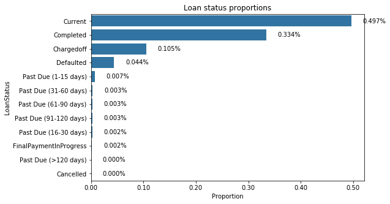

```python
#defining figure size
plt.figure(figsize=(8,5))

#taking first color as base
color = sb.color_palette()[0]

#applying the ticks to see the poportion
sb.countplot(data=df_clean, y="LoanStatus", order=loan_status_count.index, color = color)
plt.xticks(ticks*total, tick_labels)
plt.xlabel("Proportion")

#title
plt.title("Loan status proportions")

#Show each loan status proportion on right
for i in range(len(loan_status_count)):
    count = loan_status_count.values[i]
    plt.text(count + 5000, i,  f'{count/total:.3f}%', va='center', ha='center', fontsize=10)

plt.show()
```

Mainly loans status are either currently in progress or clompleted.

### What is the income range of the majority of the borrowers?

Let's see now the IncomeRange proportion of the borrowers

```python
#IncomeRange count
income_range_count = df_clean.IncomeRange.value_counts()

#nb_total of IncomeRange
total = df_clean.IncomeRange.count()
print(total)

# max IncomeRange proporttion
max_proportion = income_range_count.values[0] / total
print(max_proportion)
```

```
105390
0.30545592561
```

```python
#creating ticks and their labels
ticks = np.arange(0, max_proportion+0.05, 0.05)
tick_labels = [ f'{el:.2f}' for el in ticks]
print(ticks, tick_labels)
```

```
[ 0.    0.05  0.1   0.15  0.2   0.25  0.3   0.35] ['0.00', '0.05', '0.10', '0.15', '0.20', '0.25', '0.30', '0.35']
```

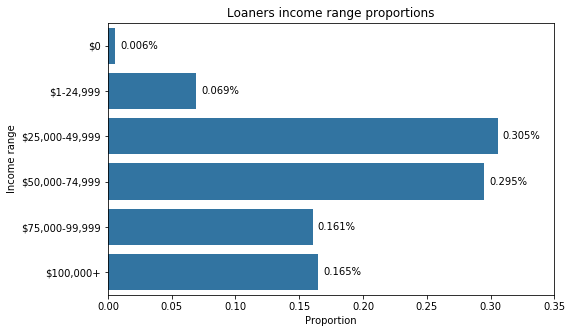

```python
#defining figure size
plt.figure(figsize=(8,5))

#taking first color as base
color = sb.color_palette()[0]
#keeping incoming range ordered
incomeRangeOrder = ["$0", "$1-24,999", "$25,000-49,999", "$50,000-74,999", "$75,000-99,999", "$100,000+"]

#applying the ticks to see the poportion
sb.countplot(data=df_clean, y="IncomeRange", color = color, order = incomeRangeOrder)
plt.xticks(ticks*total, tick_labels)
plt.ylabel("Income range")
plt.xlabel("Proportion")

#title
plt.title("Loaners income range proportions")

#Show each lncomeRange proportion on right
for index,income_range in enumerate(incomeRangeOrder):
    count = income_range_count[income_range]
    plt.text(count+2000, index,  f'{count/total:.3f}%', va='center', ha='center', fontsize=10)

plt.show()
```

The vast majority of loaners have a salary between $25 000 and $74 900 (the $25 000 - $49 999 and $50 000 - $74 900 ranges).

### How the borrower's rate is behaving ?

Let's visualize BorrowerRate distribution

```python
#show  BorrowerRate and statical information to choose a good bins
df_clean['BorrowerRate'].describe()
```

```
count    113937.000000
mean          0.192764
std           0.074818
min           0.000000
25%           0.134000
50%           0.184000
75%           0.250000
max           0.497500
Name: BorrowerRate, dtype: float64
```

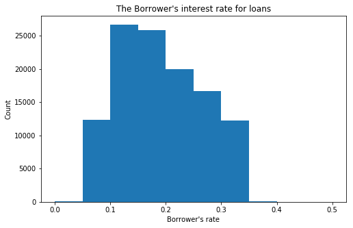

```python
plt.figure(figsize=(8, 5))

binsize = 0.05
bins = np.arange(0, df_clean['BorrowerRate'].max()+binsize, binsize)

plt.ylabel("Count")
plt.xlabel("Borrower's rate")

plt.title("The Borrower's interest rate for loans")

plt.hist(data = df_clean, x = 'BorrowerRate', bins = bins)
plt.show()
```

We can notice that the distribution of Borrower's rate is right skewed with a modal of rate between 0.1 and 0.15

### What is the most frequent term duration choosed by the borrowers?

Let's visualize the loan Term (duration) distribution

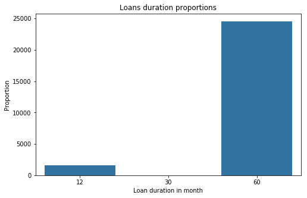

```python
#defining figure size
plt.figure(figsize=(8,5))

#taking first color as base
color = sb.color_palette()[0]

#keeping term range ordered
order = [12, 30, 60]

#applying the ticks to see the poportion
sb.countplot(data=df_clean, x="Term", color = color, order = order)
plt.xlabel("Loan duration in month")
plt.ylabel("Proportion")

#title
plt.title("Loans duration proportions")


plt.show()
```

### How the borrower's prosper score is behaving ?

Let's see the ProsperScore proportion of the borrowers

```python
#PosperScore count
prosper_score_count = df_clean.ProsperScore.value_counts()

#nb_total of PosperScore
total = df_clean.ProsperScore.count()
print(total)

# max PosperScore proporttion
max_proportion = prosper_score_count.values[0] / total
print(max_proportion)
```

```
84853
0.148433172663
```

```python
#creating ticks and their labels
ticks = np.arange(0, max_proportion+0.02, 0.02)
tick_labels = [ f'{el:.2f}' for el in ticks]
print(ticks, tick_labels)
```

```
[ 0.    0.02  0.04  0.06  0.08  0.1   0.12  0.14  0.16] ['0.00', '0.02', '0.04', '0.06', '0.08', '0.10', '0.12', '0.14', '0.16']
```

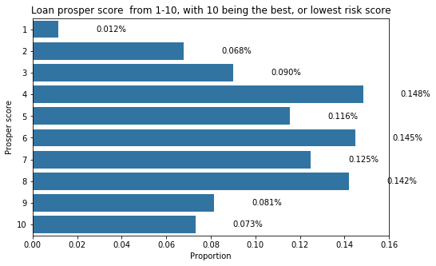

```python
#defining figure size
plt.figure(figsize=(8,5))

#taking first color as base
color = sb.color_palette()[0]
#keeping prosper score ordered
order = [number for number in range(1,11)]

#applying the ticks to see the poportion
sb.countplot(data=df_clean, y="ProsperScore", color = color, order = order)
plt.xticks(ticks*total, tick_labels)
plt.ylabel("Prosper score")
plt.xlabel("Proportion")

#title
plt.title("Loan prosper score  from 1-10, with 10 being the best, or lowest risk score")

#Show each loan prosper score proportion on right
for index,score in enumerate(order):
    count = prosper_score_count[score]
    plt.text(count+2000, index,  f'{count/total:.3f}%', va='center', ha='center', fontsize=10)

plt.show()
```

### Are the borrowers mostly homeowners?

Let's see the IsBorrowerHomeowner variable

```python
# count
counts = df_clean.IsBorrowerHomeowner.value_counts()

#nb_total
total = df_clean.IsBorrowerHomeowner.count()
print(total)

# max term proporttion
max_proportion = counts.values[0] / total
print(max_proportion)
```

```
113937
0.504471769487
```

```python
#creating ticks and their labels
ticks = np.arange(0, max_proportion+0.1, 0.1)
tick_labels = [ f'{el:.2f}' for el in ticks]
print(ticks, tick_labels)
```

```
[ 0.   0.1  0.2  0.3  0.4  0.5  0.6] ['0.00', '0.10', '0.20', '0.30', '0.40', '0.50', '0.60']
```

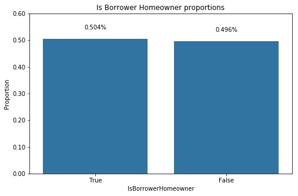

```python
#defining figure size
plt.figure(figsize=(8,5))

#taking first color as base
color = sb.color_palette()[0]

#applying the ticks to see the poportion
sb.countplot(data=df_clean, x="IsBorrowerHomeowner", color = color, order = counts.index)
plt.yticks(ticks*total, tick_labels)
plt.ylabel("Proportion")

#title
plt.title("Is Borrower Homeowner proportions")

#Show each term proportion on top
for index,count in enumerate(counts.index):
    count = counts.values[index]
    plt.text(index,count+5000,  f'{count/total:.3f}%', va='center', ha='center', fontsize=10)

plt.show()
```

The home owner attributes distribution of borrowers is approximately equal.

### Are the revenues of the borrowers for the most part verifiable?

Let's see the IncomeVerifiable variable distribution

```python
# count
counts = df_clean.IncomeVerifiable.value_counts()

#nb_total
total = df_clean.IncomeVerifiable.count()
print(total)

# max term proporttionµ
max_proportion = counts.values[0] / total
print(max_proportion)
```

```
113937
0.923914092876
```

```python
#creating ticks and their labels
ticks = np.arange(0, max_proportion+0.2, 0.2)
tick_labels = [ f'{el:.2f}' for el in ticks]
print(ticks, tick_labels)
```

```
[ 0.   0.2  0.4  0.6  0.8  1. ] ['0.00', '0.20', '0.40', '0.60', '0.80', '1.00']
```

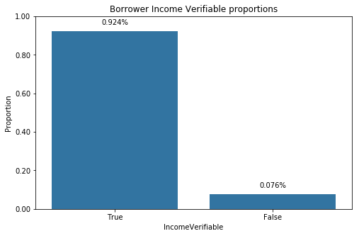

```python
#defining figure size
plt.figure(figsize=(8,5))

#taking first color as base
color = sb.color_palette()[0]

#applying the ticks to see the poportion
sb.countplot(data=df_clean, x="IncomeVerifiable", color = color, order = counts.index)
plt.yticks(ticks*total, tick_labels)
plt.ylabel("Proportion")

#title
plt.title("Borrower Income Verifiable proportions")

#Show each term proportion on top
for index,count in enumerate(counts.index):
    count = counts.values[index]
    plt.text(index,count+5000,  f'{count/total:.3f}%', va='center', ha='center', fontsize=10)

plt.show()
```

Mainly borower's incomes are verifiable

#### Have the borrowers a large number of open credit at the time the credit profile was pulled?

Let's visualize OpenCreditLines (Number of open credit lines at the time the credit profile was pulled) distribution

```python
#show  OpenCreditLines and statical information to choose a good bins
df_clean['OpenCreditLines'].describe()
```

```
count    113937.000000
mean          8.642153
std           5.374413
min           0.000000
25%           5.000000
50%           8.000000
75%          12.000000
max          54.000000
Name: OpenCreditLines, dtype: float64
```

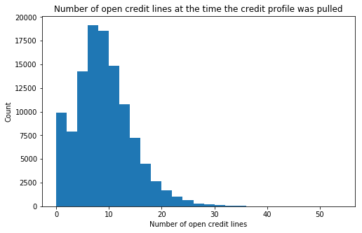

```python
plt.figure(figsize=(8, 5))

binsize = 2
bins = np.arange(0, df_clean['OpenCreditLines'].max()+binsize, binsize)

plt.ylabel("Count")
plt.xlabel("Number of open credit lines")

plt.title("Number of open credit lines at the time the credit profile was pulled")

plt.hist(data = df_clean, x = 'OpenCreditLines', bins = bins)
plt.show()
```

We can notice that the distribution is right skewed with a modal of rate between 6 and 8. So many of the borrower's have a large number of open credit lines at the time their credit profile was pulled.

### Have the borrowers a large number of delinquencies during the last 7 years?

Let's visualize the DelinquenciesLast7Years of borrowers distribution

```python
#show  DelinquenciesLast7YearsDelinquenciesLast7Years and statical information to choose a good bins
df_clean['DelinquenciesLast7Years'].describe()
```

```
count    113937.000000
mean          4.118881
std          10.123325
min           0.000000
25%           0.000000
50%           0.000000
75%           3.000000
max          99.000000
Name: DelinquenciesLast7Years, dtype: float64
```

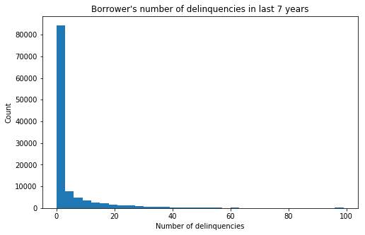

```python
plt.figure(figsize=(8, 5))

binsize = 3
bins = np.arange(0, df_clean['DelinquenciesLast7Years'].max()+binsize, binsize)

plt.ylabel("Count")
plt.xlabel("Number of delinquencies")

plt.title("Borrower's number of delinquencies in last 7 years")

plt.hist(data = df_clean, x = 'DelinquenciesLast7Years', bins = bins)
plt.show()
```

We can notice that the distribution is very right skewed with a modal of delinquency between 0 and 3. So many of the borrower's don't have a large number of delinquencies at the time their credit profile was pulled.

### Have the borrowers a high amount of debt considering their income?

Let's visualize Borrower DebtToIncomeRatio distribution

```python
#show  DebtToIncomeRatio and statical information to choose a good bins
df_clean['DebtToIncomeRatio'].describe()
```

```
count    105383.000000
mean          0.275947
std           0.551759
min           0.000000
25%           0.140000
50%           0.220000
75%           0.320000
max          10.010000
Name: DebtToIncomeRatio, dtype: float64
```

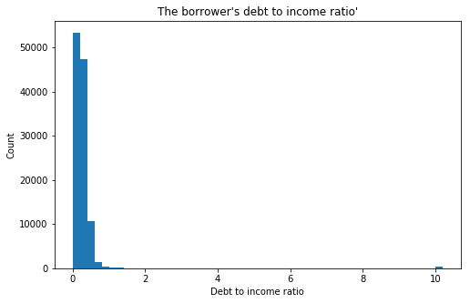

```python
df_clean['DebtToIncomeRatio'] = df_clean['DebtToIncomeRatio'].fillna(0.0).astype(float)

plt.figure(figsize=(8, 5))

binsize = 0.2
bins = np.arange(0, df_clean['DebtToIncomeRatio'].max()+binsize, binsize)

plt.ylabel("Count")
plt.xlabel("Debt to income ratio")

plt.title("The borrower's debt to income ratio'")

plt.hist(data = df_clean, x = 'DebtToIncomeRatio', bins = bins)

plt.show()
```

Let's check why we have this distribution

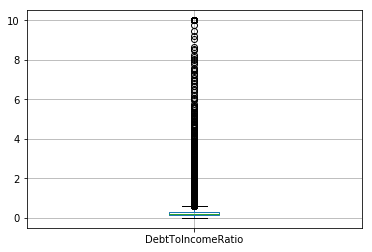

```python
df_clean.boxplot(column=['DebtToIncomeRatio'])
```

We can notice that we have many and many outliers. Let's reduce our bins maximum value to 0.5

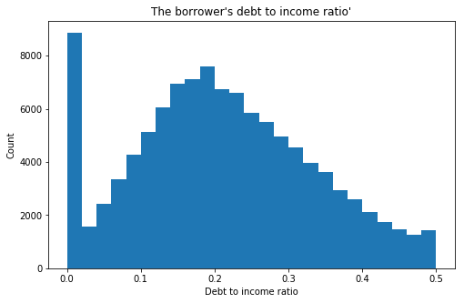

```python
plt.figure(figsize=(8, 5))

binsize = 0.02
bins = np.arange(0, 0.5+binsize, binsize)

plt.ylabel("Count")
plt.xlabel("Debt to income ratio")

plt.title("The borrower's debt to income ratio'")

plt.hist(data = df_clean, x = 'DebtToIncomeRatio', bins = bins)

plt.show()
```

We can notice that the distribution of Borrower's debt to income ration have a modal between 0 and 0.02. With mainly debt to income ratio between 0 and 0.5 we can say that most of the borrowers don't have a high amount of debt considering their income.

### What is the month income of the most borrowers?

Let's visualize Borrower Stated Monthly Income distribution

```python
#show  StatedMonthlyIncome and statical information to choose a good bins
df_clean['StatedMonthlyIncome'].describe()
```

```
count    1.139370e+05
mean     5.608026e+03
std      7.478497e+03
min      0.000000e+00
25%      3.200333e+03
50%      4.666667e+03
75%      6.825000e+03
max      1.750003e+06
Name: StatedMonthlyIncome, dtype: float64
```

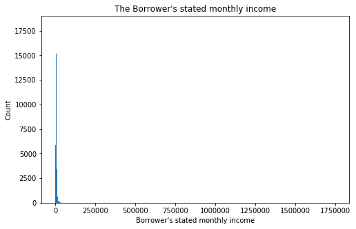

```python
plt.figure(figsize=(8, 5))

binsize = 1000
bins = np.arange(0, df_clean['StatedMonthlyIncome'].max()+binsize, binsize)

plt.ylabel("Count")
plt.xlabel("Borrower's stated monthly income")

plt.title("The Borrower's stated monthly income")

plt.hist(data = df_clean, x = 'StatedMonthlyIncome', bins = bins)
plt.show()
```

Let's check why we have this distribution

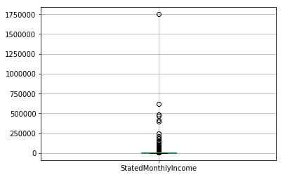

```python
df_clean.boxplot(column=['StatedMonthlyIncome'])
```

We can notice that we have many outliers. Let's reduce our bins maximum value to 10 000

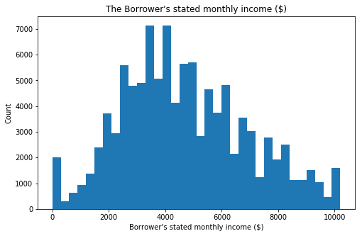

```python
plt.figure(figsize=(8, 5))

binsize = 300
bins = np.arange(0, 10000+binsize, binsize)

plt.ylabel("Count")
plt.xlabel("Borrower's stated monthly income ($)")

plt.title("The Borrower's stated monthly income ($)")

plt.hist(data = df_clean, x = 'StatedMonthlyIncome', bins = bins)
plt.show()
```

Now we notice that we have two modals around 3000$ and 4000$

### What is the monthly loan payment of many borrowers ?

Let's visualize Borrower Monthly Loan Payment distribution

```python
#show  MonthlyLoanPayment and statical information to choose a good bins
df_clean['MonthlyLoanPayment'].describe()
```

```
count    113937.000000
mean        272.475783
std         192.697812
min           0.000000
25%         131.620000
50%         217.740000
75%         371.580000
max        2251.510000
Name: MonthlyLoanPayment, dtype: float64
```

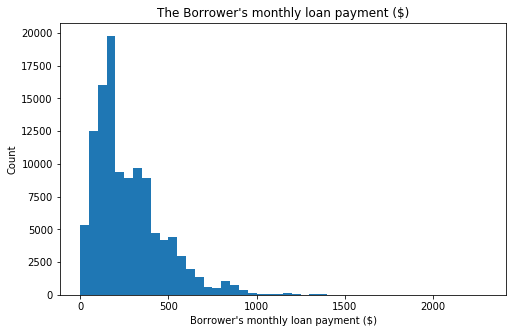

```python
plt.figure(figsize=(8, 5))

binsize = 50
bins = np.arange(0, df_clean['MonthlyLoanPayment'].max()+binsize, binsize)

plt.ylabel("Count")
plt.xlabel("Borrower's monthly loan payment ($)")

plt.title("The Borrower's monthly loan payment ($)")

plt.hist(data = df_clean, x = 'MonthlyLoanPayment', bins = bins)
plt.show()
```

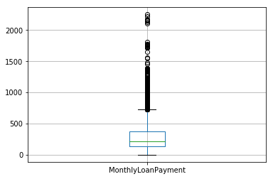

```python
df_clean.boxplot(column=['MonthlyLoanPayment'])
```

By reducing the maximum to 800 we have:

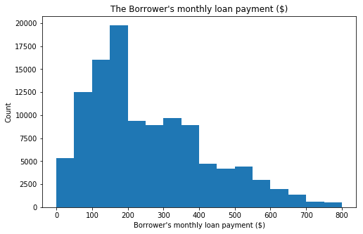

```python
plt.figure(figsize=(8, 5))

binsize = 50
bins = np.arange(0, 800+binsize, binsize)

plt.ylabel("Count")
plt.xlabel("Borrower's monthly loan payment ($)")

plt.title("The Borrower's monthly loan payment ($)")

plt.hist(data = df_clean, x = 'MonthlyLoanPayment', bins = bins)
plt.show()
```

The monthly loan payment of many borrower's is between 150$ and 200$

### How the borrower's loan original amount is behaving ?

Let's visualize Loan Original Amount distribution

```python
#show MonthlyLoanPayment and statical information to choose a good bins
df_clean['LoanOriginalAmount'].describe()
```

```
count    113937.00000
mean       8337.01385
std        6245.80058
min        1000.00000
25%        4000.00000
50%        6500.00000
75%       12000.00000
max       35000.00000
Name: LoanOriginalAmount, dtype: float64
```

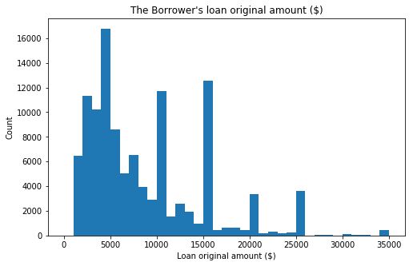

```python
plt.figure(figsize=(8, 5))

binsize = 1000
bins = np.arange(0, df_clean['LoanOriginalAmount'].max()+binsize, binsize)

plt.ylabel("Count")
plt.xlabel("Loan original amount ($)")

plt.title("The Borrower's loan original amount ($)")

plt.hist(data = df_clean, x = 'LoanOriginalAmount', bins = bins)
plt.show()
```

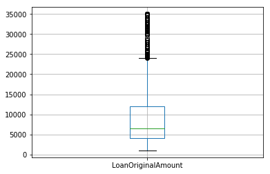

```python
df_clean.boxplot(column=['LoanOriginalAmount'])
```

By reducing the maximum value to 24000 we have:

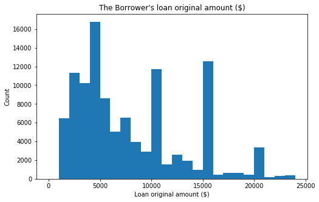

```python
plt.figure(figsize=(8, 5))

binsize = 1000
bins = np.arange(0, 24000+binsize, binsize)

plt.ylabel("Count")
plt.xlabel("Loan original amount ($)")

plt.title("The Borrower's loan original amount ($)")

plt.hist(data = df_clean, x = 'LoanOriginalAmount', bins = bins)
plt.show()
```

Let's apply a log transfomartion to see if we can improve our distribution shape.

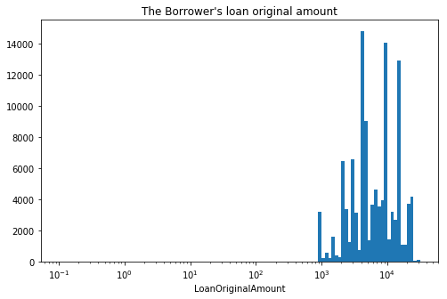

```python
# there's a long tail in the distribution, so let's put it on a log scale instead
log_binsize = 0.05
bins = 10 ** np.arange(-1, np.log10(df_clean['LoanOriginalAmount'].max()+log_binsize), log_binsize)

plt.figure(figsize=[8, 5])
plt.hist(data = df_clean, x = 'LoanOriginalAmount', bins = bins)
plt.xscale('log')
plt.xlabel('LoanOriginalAmount')
plt.title("The Borrower's loan original amount")

plt.show()
```

With this we always have three main spike but our distribution is not more rightr skewed.

### Discuss the distribution(s) of your variable(s) of interest. Were there any unusual points? Did you need to perform any transformations?

> The DebtToIncomeRatio, StatedMonthlyIncome, MonthlyLoanPayment and LoanOriginalAmount took on a large range of values and have many outliers, so I looked at the data by setting a maximum range value according the boxplot start outliers. With these change, the plots are better.

### Of the features you investigated, were there any unusual distributions? Did you perform any operations on the data to tidy, adjust, or change the form of the data? If so, why did you do this?

> I apply a log transformation to the Borrower's loan original amount to better visualize the distribution. I notice that they are always same numbers of spike but distribution were not more right skewed.

## Bivariate Exploration

### Are the differents features corralated? And what are their relationships?

To start off with, I want to look at the pairwise correlations present between features in the data.

```python
numeric_vars = ['BorrowerRate', 'OpenCreditLines', 'DelinquenciesLast7Years', 'DebtToIncomeRatio', 'StatedMonthlyIncome', 'LoanOriginalAmount', 'MonthlyLoanPayment']
categoric_vars = ['LoanStatus', 'Term', 'ProsperScore','IsBorrowerHomeowner','IncomeRange','IncomeVerifiable']
```

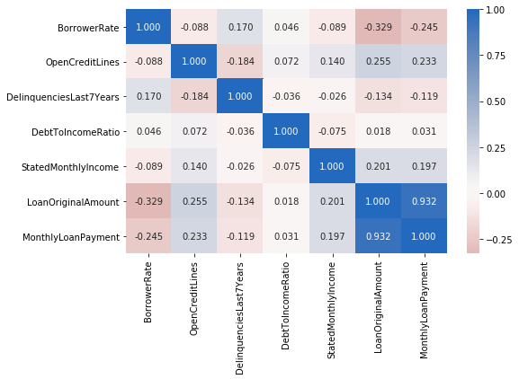

```python
# correlation plot
plt.figure(figsize = [8, 5])
sb.heatmap(df_clean[numeric_vars].corr(), annot = True, fmt = '.3f',
           cmap = 'vlag_r', center = 0)
plt.show()
```

```
loans.shape= (113937, 14)
matrix_samp.shape= (2000, 14)
```

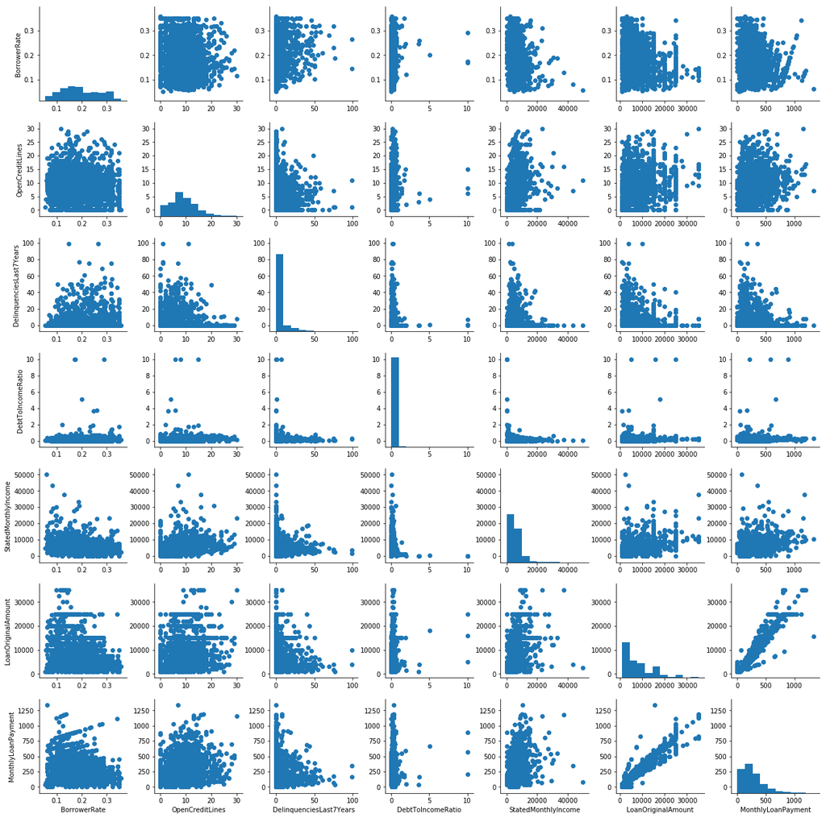

```python
# plot matrix: sample 2000 loans so that plots are clearer and they render faster
print("loans.shape=",df_clean.shape)
df_clean_sample = df_clean.sample(n=2000, replace = False)
print("matrix_samp.shape=",df_clean_sample.shape)

g = sb.PairGrid(data = df_clean_sample, vars = numeric_vars)
g = g.map_diag(plt.hist, bins = 10);
g.map_offdiag(plt.scatter)
```

I was expecting more relations between the variable but i only got one between the LoanOriginalAmount and the MonthlyLoanPayment ( which is normal). More is the loan original amount more is the monthly loan payment.

Let's move on to looking at how categorical variables correlate with the numerical variables.

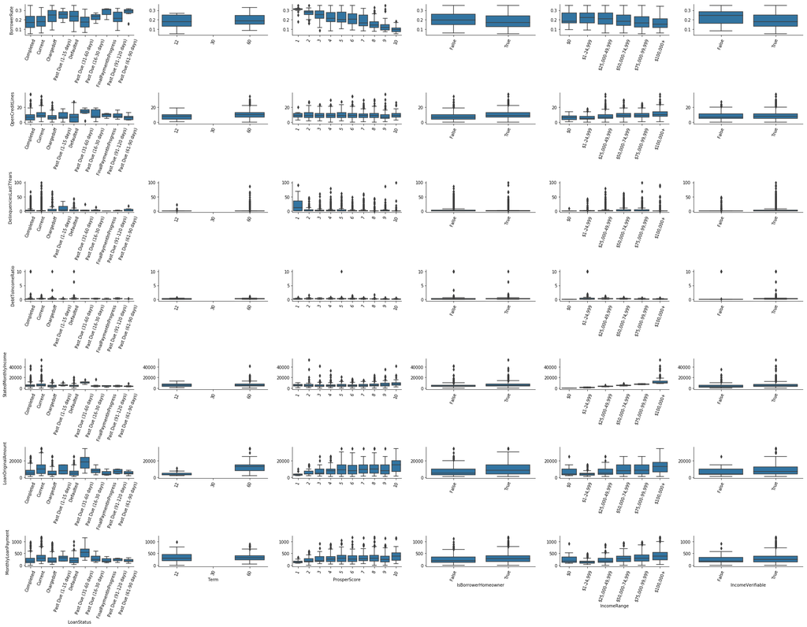

```python
# plot matrix of numeric features against categorical features.
# can use a larger sample since there are fewer plots and they're simpler in nature.

df_clean_sample = df_clean.sample(n=2000, replace = False)


def boxgrid(x, y, **kwargs):
    """ Quick hack for creating box plots with seaborn's PairGrid. """
    default_color = sb.color_palette()[0]
    sb.boxplot(x=x, y=y, color=default_color)
    plt.xticks(rotation=70)

plt.figure(figsize = [16, 20])
g = sb.PairGrid(data = df_clean_sample, y_vars = numeric_vars, x_vars = categoric_vars,
                size = 3, aspect = 1.5)
g.map(boxgrid)

plt.tight_layout()

plt.show();
```

With this we can notice a relationship between the prosper score and the borrower rate, the prosper score and the loan original amount, the income range and the borrower rate, the income range and the monthly loan payment, the income range and the original loan amount, the income range and the open credit lines and the income range and the stated monthly income. Let's best visualize these relationships.

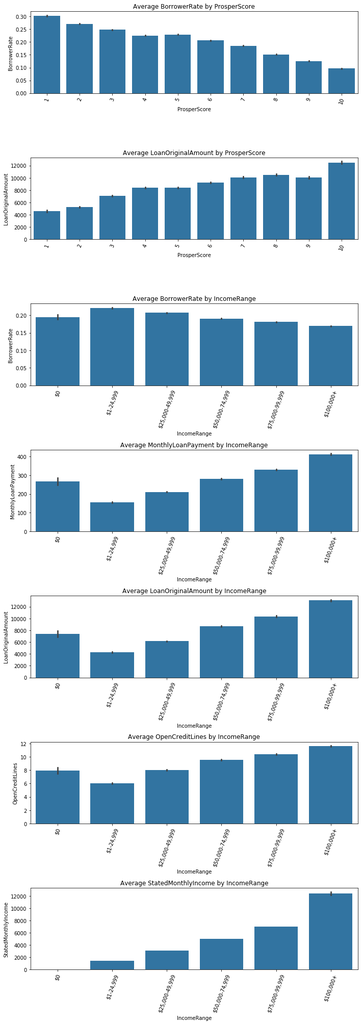

```python
def barplot(x, y):
    """ ploting barplots """
    default_color = sb.color_palette()[0]
    sb.barplot(data=df_clean, x=x, y=y, color=default_color)
    plt.title('Average '+ y + ' by '+ x)
    plt.xticks(rotation=70)

plt.figure(figsize = [10, 28])

#relations to visualize
to_plots = [{'x':'ProsperScore', 'y':'BorrowerRate'}, {'x':'ProsperScore', 'y':'LoanOriginalAmount'},
            {'x':'IncomeRange', 'y':'BorrowerRate'}, {'x':'IncomeRange', 'y':'MonthlyLoanPayment'} ,
            {'x':'IncomeRange', 'y':'LoanOriginalAmount'}, {'x':'IncomeRange', 'y':'OpenCreditLines'},
            {'x':'IncomeRange', 'y':'StatedMonthlyIncome'}]

for index, to_plot in enumerate(to_plots):
    plt.subplot(7, 1, index+1)
    barplot(to_plot['x'], to_plot['y'])

plt.tight_layout()

plt.show();
```

We can conclude that:

- The worse is the posper score (10 to 1), the higher is the borrower rate
- The best is the prosper score (1 to 10), the higher is the loan original amount

**For income range except for $0 range:**

- The best is the income range, the lower is the borrower rate
- The best is the income range, the higner are the *loan original amount*, the *monthly loan payment*, the *borrower open credit lines* and the *borrower stated monthly income*.

Finally, let's look at relationships of the LoanStatus and other categorical features and of income range and prosper score with some categorical features.

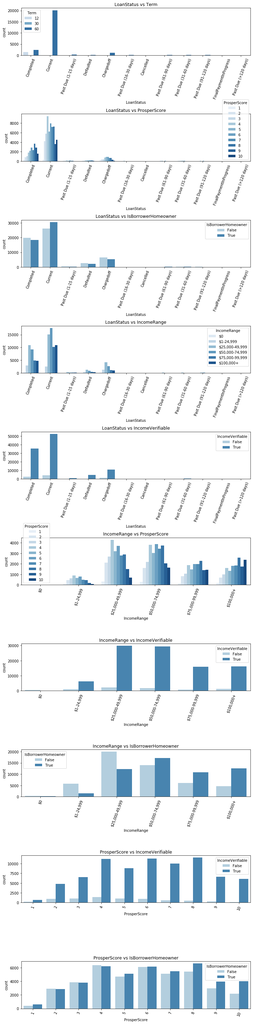

```python
def countplot(x, y):
    """ ploting barplots """
    sb.countplot(data = df_clean, x = x, hue = y, palette = 'Blues')
    plt.title( x + ' vs '+ y)
    plt.xticks(rotation=70)

plt.figure(figsize = [10, 40])

#relations to visualize
to_plots = [{'x':'LoanStatus', 'y':'Term'}, {'x':'LoanStatus', 'y':'ProsperScore'},
            {'x':'LoanStatus', 'y':'IsBorrowerHomeowner'}, {'x':'LoanStatus', 'y':'IncomeRange'} ,
            {'x':'LoanStatus', 'y':'IncomeVerifiable'}, {'x':'IncomeRange', 'y':'ProsperScore'},
            {'x':'IncomeRange', 'y':'IncomeVerifiable'}, {'x':'IncomeRange', 'y':'IsBorrowerHomeowner'},
           {'x':'ProsperScore', 'y':'IncomeVerifiable'}, {'x':'ProsperScore', 'y':'IsBorrowerHomeowner'}]

for index, to_plot in enumerate(to_plots):
    plt.subplot(10, 1, index+1)
    countplot(to_plot['x'], to_plot['y'])

plt.tight_layout()

plt.show();
```

### Talk about some of the relationships you observed in this part of the investigation. How did the feature(s) of interest vary with other features in the dataset?

> During this investigation, i was surprised that there was'nt relationship between the feature of interest and others features. However i observed some relationships between other features like the LoanOriginalAmount and the MonthlyLoanPayment, the the income range and the open credit lines ... I hope that the loan status will be linked to the others via multivariate relationships.

### Did you observe any interesting relationships between the other features (not the main feature(s) of interest)?

> They are many relationships between the other features. We have a relationship between the prosper score and the borrower rate, the prosper score and the loan original amount, the income range and the borrower rate, the income range and the monthly loan payment, the income range and the original loan amount, the income range and the open credit lines, the income range and the stated monthly income and the LoanOriginalAmount and the MonthlyLoanPayment.

> Those that i found interesting are between:
> - The prosper score and the borrower rate: the worse is the posper score (10 to 1), the higher is the borrower rate
> - The prosper score and the loan original amount: the best is the prosper score (1 to 10), the higher is the loan original amount
> - The income range and the borrower rate: the best is the income range, the lower is the borrower rate
> - The income range and the loan original amount: the best is the income range, the higner is the loan original amount.
> - The income range and the borrower open credit lines: the best is the income range, the higner are the the borrower open credit lines.

> I think that these bivariate relationships will be further corelated through multivariate relations.

## Multivariate Exploration

In this part, I want to check if the loan status is correlated with others features by looking at the relationship of the:

- loan status with the DelinquenciesLast7Years and the DebtToIncomeRatio
- loan status with the ProsperScore and the BorrowerRate
- loan status with the borrower rate and Income range
- loan status with StatedMonthlyIncome and MonthlyLoanPayment
- ProsperScore with the BorrowerRate and DebtToIncomeRatio
- ProsperScore with the BorrowerRate and DelinquenciesLast7Years
- prosper score with DelinquenciesLast7Years and DebtToIncomeRatio
- ProsperScore with the BorrowerRate, LoanOriginalAmou and IncomeRange

### Relationships of the loan status with DelinquenciesLast7Years and DebtToIncomeRatio

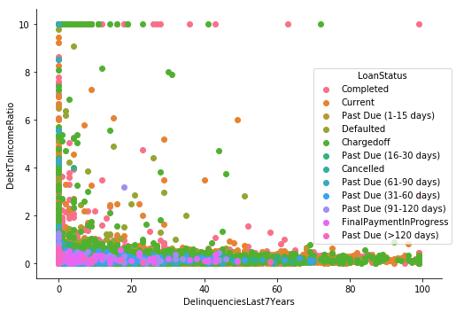

```python
g = sb.FacetGrid(data = df_clean, hue = 'LoanStatus', size = 5)
g.map(plt.scatter, 'DelinquenciesLast7Years', 'DebtToIncomeRatio')
g.add_legend()
plt.tight_layout()
plt.show()
```

### Relationships of the loan status with ProsperScore and BorrowerRate

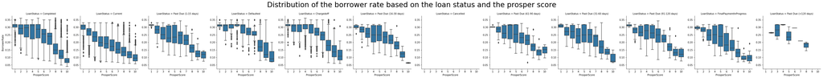

```python
prosperScoreOrder = [number for number in range(1,11)]
g = sb.FacetGrid(data = df_clean, col = 'LoanStatus', size = 4)
g.map(sb.boxplot, 'ProsperScore', 'BorrowerRate', order=prosperScoreOrder)
plt.suptitle('Distribution of the borrower rate based on the loan status and the prosper score', size=30, y=1.12)
plt.tight_layout()
plt.show()
```

Let's see the same relationship with another plot

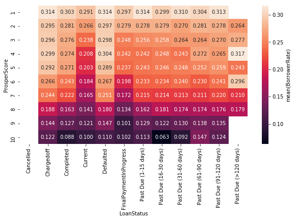

```python
plt.figure(figsize = [10,5])

cat_means = df_clean.groupby(['LoanStatus', 'ProsperScore']).mean()['BorrowerRate']
cat_means = cat_means.reset_index(name = 'BorrowerRateAvg')
cat_means = cat_means.pivot(index = 'ProsperScore', columns = 'LoanStatus',
values = 'BorrowerRateAvg')
sb.heatmap(cat_means, annot = True, fmt = '.3f',
cbar_kws = {'label' : 'mean(BorrowerRate)'})
plt.show()
```

Here we can see again the relationship between the prosper score and the borrower rate. For the loan we can't say that the those two features has an impact on it status.

### Relationships of the Loan status with the borrower rate and Income range

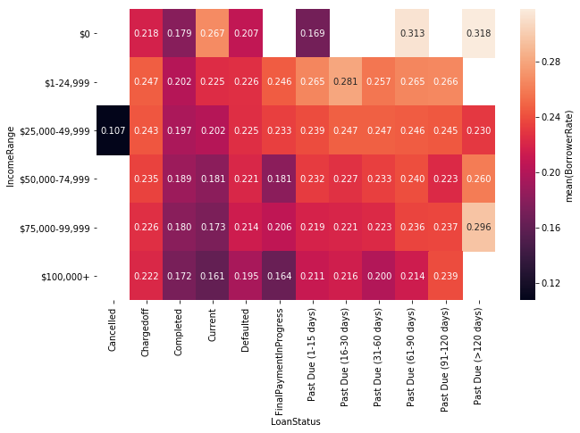

```python
plt.figure(figsize = [10,6])

cat_means = df_clean.groupby(['LoanStatus', 'IncomeRange']).mean()['BorrowerRate']
cat_means = cat_means.reset_index(name = 'BorrowerRateAvg')
cat_means = cat_means.pivot(index = 'IncomeRange', columns = 'LoanStatus',
values = 'BorrowerRateAvg')
sb.heatmap(cat_means, annot = True, fmt = '.3f',
cbar_kws = {'label' : 'mean(BorrowerRate)'})
plt.show()
```

We can notice that most of the past due loan status have a high borrower rate and most of the current and completed status have a low borrower rate.

### Relationships of the loan status with StatedMonthlyIncome and MonthlyLoanPayment

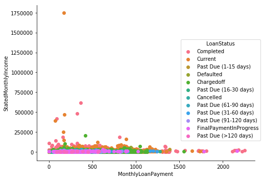

```python
g = sb.FacetGrid(data = df_clean, hue = 'LoanStatus', size = 5)
g.map(plt.scatter, 'MonthlyLoanPayment', 'StatedMonthlyIncome')
g.add_legend()
plt.tight_layout()
plt.show()
```

There is no relationship between those three variables.

### Relationships of the ProsperScore with the BorrowerRate and DebtToIncomeRatio

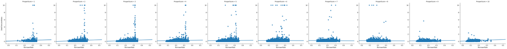

```python
sb.lmplot(data=df_clean, x="BorrowerRate", y="DebtToIncomeRatio", col="ProsperScore")
# plt.title('Relation between distance and age based on user type and member gender')
plt.show()
```

There is no relationship between the debt to income ratio and the prosper score and the borrower rate. Most of the borrowers have a small debt to income ratio ( whic means that they daon't have a large amount of debt).

### Relationships of the ProsperScore with the BorrowerRate and DelinquenciesLast7Years

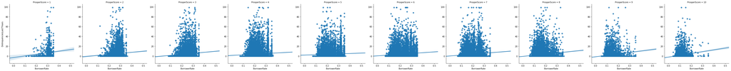

```python
sb.lmplot(data=df_clean, x="BorrowerRate", y="DelinquenciesLast7Years", col="ProsperScore")
# plt.title('Relation between distance and age based on user type and member gender')
plt.show()
```

There is no relationship between the delenquencies last years and the prosper score and the borrower rate.

### Relationships of the prosper score with DelinquenciesLast7Years and DebtToIncomeRatio

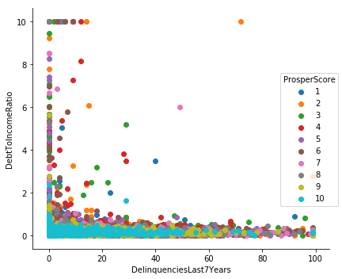

```python
g = sb.FacetGrid(data = df_clean, hue = 'ProsperScore', size = 5)
g.map(plt.scatter, 'DelinquenciesLast7Years', 'DebtToIncomeRatio')
g.add_legend()
plt.tight_layout()
plt.show()
```

### Relationships of the ProsperScore with the BorrowerRate, the IncomeRange and the loan original amount

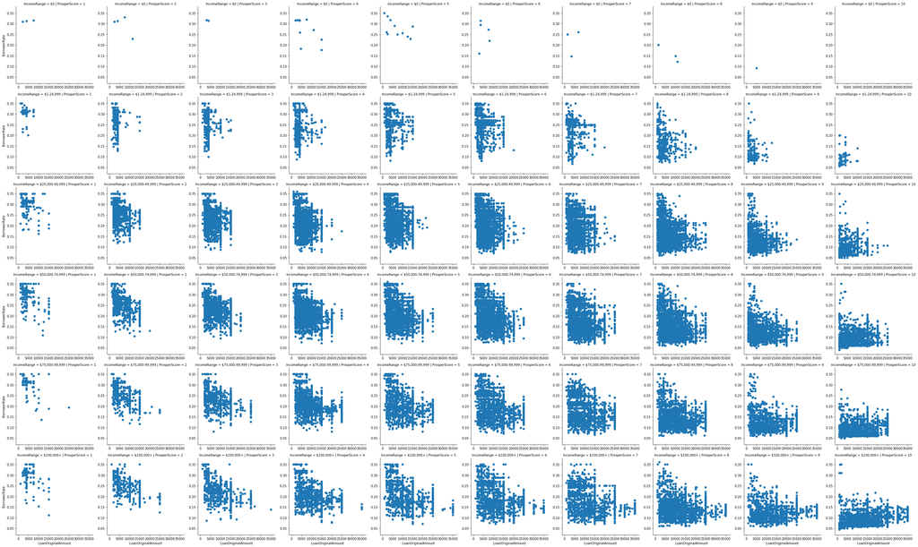

```python
g = sb.FacetGrid(data = df_clean, col = 'ProsperScore', row='IncomeRange', size = 4)
g.map(plt.scatter, 'LoanOriginalAmount', 'BorrowerRate')
plt.show()
```

Here we can notice that more is the prosper score and the income range , the lower is the borrower rate and the higner is the loan original amount.

### Were there any interesting or surprising interactions between features?

> No and I am surprised

```python
#Let store new dataset to csv file

df_clean.to_csv('cleanProsperLoanData.csv', index=False)
```